# HappyDB Text Mining

HappyDB is "a corpus of 100,000 crowd-sourced happy moments." In this project, I will analyze the text content and the author demographics by performing exploratory data analysis, topic modeling, and document clustering.

## Contents

- [Part 1: Load Data](#Part-1:-Load-Data)
- [Part 2: Exploratory Data Analysis](#Part-2:-Exploratory-Data-Analysis)
- [Part 3: TF-IDF](#Part-3:-TF-IDF)
- [Part 4: Topic Modeling - Latent Dirichlet Allocation](#Part-4:-LDA-Topic-Modeling)
- [Part 5: K-means clustering](#Part-5:-K-Means-Clustering)

# Part 1: Load Data

```python
import warnings
warnings.filterwarnings("ignore")
import pandas as pd
import nltk
import re
import os

import matplotlib.pyplot as plt
import seaborn as sns
import numpy as np
pd.set_option('display.max_columns', None)
pd.options.display.max_rows = 999
```

import the processed happy moments data.

```python
happy_mn = pd.read_csv("../output/processed_moments.csv")
demographic = pd.read_csv("../data/demographic.csv")
# happy_mn.head()
# demographic.head()
```

```python
# join two dataframes
new_happy_mn = pd.merge(happy_mn,demographic,on="wid")
new_happy_mn.head(3)
```

|  | hmid | wid | reflection_period | original_hm | cleaned_hm | modified | num_sentence | ground_truth_category | predicted_category | id | text | age | country | gender | marital | parenthood |
| --- | --- | --- | --- | --- | --- | --- | --- | --- | --- | --- | --- | --- | --- | --- | --- | --- |
| 0 | 27673 | 2053 | 24h | I went on a successful date with someone I fel... | I went on a successful date with someone I fel... | True | 1 | NaN | affection | 1 | successfully date sympathy connected | 35 | USA | m | single | n |
| 1 | 27873 | 2053 | 24h | I played a new game that was fun and got to en... | I played a new game that was fun and got to en... | True | 1 | NaN | leisure | 201 | played game fun enjoyed mechanical | 35 | USA | m | single | n |
| 2 | 28073 | 2053 | 24h | I listened to some music and heard an entire a... | I listened to some music and heard an entire a... | True | 1 | NaN | leisure | 401 | listening music heard entire album hadnt heard | 35 | USA | m | single | n |

# Part 2: Exploratory Data Analysis

```python
total = len(new_happy_mn)
users = len(new_happy_mn.wid.unique())
print "There are a total of", total, "sentences of happy moments and", \
users, "unique users. \nOn average, each user contributes", total/users, "sentences."
```

```
There are a total of 100392 sentences of happy moments and 10841 unique users.
On average, each user contributes 9 sentences.
```

## 2.1 Gender

Males contributed **57597 (57.41%)** happy moments to the corpus, and females contributed **42019 (41.88%)** moments. The authors of **697 (0.69%)** moments were not willing to disclose their genders.

Each sentence is predicted to belong to one of the following categories: affection, achievement, bonding, enjoy the moment, exercise, leisure, and nature. A cross tabulation of gender and predicted category showed that females disproportionally contributed to moments in affection (50.37%) and nature (48.23%). Even though females' proportion in the author population is only 41.88%, they contributed to about half of the happy moments related to affection and nature, which reveals females' tendency to value intimate interpersonal relationships more than males, and suggests that females are more likely to appreciate happiness related to nature.

On the other hand, males have disproportionally high contribution to moments in exercise (68.62%), leisure (64.76%), and achievement (62.31%), which goes with the stereotype that males are more ambitious and active. Males are also slightly more likely to mention moments in bonding (60.23%) and "enjoy-the-moment" (60.38%) kind of happiness than females, although not by a great amount.

I did not exclude those who did not disclose the gender from the analysis, because these people might have special characteristics, such as bisexual identification. This group has disproportionally high contribution to moments in enjoy-the-moment (0.86%), exercise (0.84%), and bonding (0.82%).

```python
new_happy_mn.gender.value_counts()
```

```
m    57597
f    42019
o      697
Name: gender, dtype: int64
```

```
Text(0.5,1,'Gender Distribution')
```

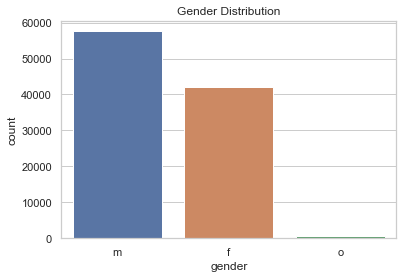

```python
sns.set(style="whitegrid")
ax = sns.countplot("gender", data=new_happy_mn)
ax.set_title("Gender Distribution")
```

| gender predicted_category | f | m | o |
| --- | --- | --- | --- |
| achievement | 36.943239 | 62.309986 | 0.746775 |
| affection | 50.376513 | 49.060916 | 0.562571 |
| bonding | 38.951101 | 60.227697 | 0.821202 |
| enjoy_the_moment | 38.767790 | 60.376509 | 0.855702 |
| exercise | 30.543933 | 68.619247 | 0.836820 |
| leisure | 34.608672 | 64.760371 | 0.630957 |
| nature | 48.236571 | 51.112317 | 0.651112 |

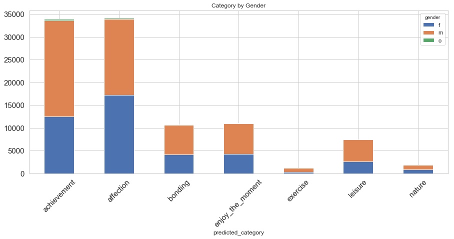

```python
%matplotlib inline
pd.crosstab(new_happy_mn.predicted_category, new_happy_mn.gender).plot(kind="bar", stacked="True", figsize=(15,6),
                                                                       fontsize=15, rot=45, title="Category by Gender")
pd.crosstab(new_happy_mn.predicted_category, new_happy_mn.gender).apply(lambda r: r/r.sum()*100, axis=1)
```

## 2.2 Average Word Count

The average word count of each moment is 18.37, and there is no significant difference in sentence length between males (mean=18.37) and females (18.41).

```python
word_count = happy_mn.cleaned_hm.apply(lambda x: len(x.split(" ")))
print "Summary of word count of all sentences: \n"
print word_count.describe()
wc_df = new_happy_mn[['gender', 'cleaned_hm']]
wc_df['word_count'] = word_count
print "\n\nSummary of word count by gender: \n"
print wc_df.groupby("gender").describe()
```

```
Summary of word count of all sentences:

count    100392.000000
mean         18.374104
std          21.519539
min           2.000000
25%           9.000000
50%          14.000000
75%          21.000000
max        1155.000000
Name: cleaned_hm, dtype: float64


Summary of word count by gender:

       word_count
            count       mean        std  min  25%   50%   75%     max
gender
f         42019.0  18.406340  22.252692  2.0  9.0  14.0  21.0  1155.0
m         57597.0  18.365661  21.055735  2.0  9.0  14.0  21.0   981.0
o           697.0  17.157819  13.607524  2.0  9.0  13.0  21.0   124.0
```

For the sake of clear visualization, I filtered the outliers using a threshold of 0.98 quantile.

```python
q = wc_df["word_count"].quantile(0.98)
wc_df = wc_df[wc_df["word_count"] < q]
```

```
Text(0.5,1,'Word Count Distribution by Gender')
```

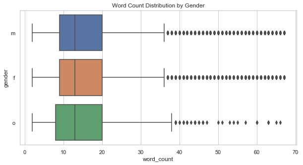

```python
plt.figure(figsize=(10,5))
sns.boxplot(x = "word_count", y = "gender", data = wc_df).set_title("Word Count Distribution by Gender")
```

## 2.3 What kind of happiness lasts and what fades away

**Category**: As mentioned earlier, each sentence is assigned to one of the categories by a prediction algorithm. Let's look at the popularity of each category by plotting a bargraph of all the predicted categories. (Note: each sentence belongs to a category predicted by an algorithm, but only 14107 out of the 100392 moments are manually labelled).

The bargraph showed that the two most popular categories are affection and achievement, followed by enjoy-the-moment, bonding, and leisure.

**Reflection period:** Each sentence has an associated reflection period of 24 hours or 3 months, and the author can only recall happy moments occurring within the specified time frame. There are 50646 moments recalled within 3 months, and 49746 recalled within the last 24 hours. Here we analyze what categories of moments are more likely to bring people happiness in the long run versus the short run.

The bargraph "Predicted Category and Reflection Period" showed that more moments in achievement and affection are recalled in the long run than the short run, meaning that these moments are more salient in people's memory in the long run, compared to other categories.

On the other hand, enjoy-the-moment and leisure moments are more likely to be remembered within 24 hours, which makes sense, because these happy moments are usually more trivial (e.g., watched a good movie, had a good meal, etc.) than moments of achievement (e.g., got promoted, got good grade) and affection (e.g., strong emotion, connection).

```python
print happy_mn.ground_truth_category.count()
print len(happy_mn)
```

```
14107
100392
```

```python
happy_mn.reflection_period.value_counts()
```

```
3m     50646
24h    49746
Name: reflection_period, dtype: int64
```

```
Text(0,0.5,'count')
```

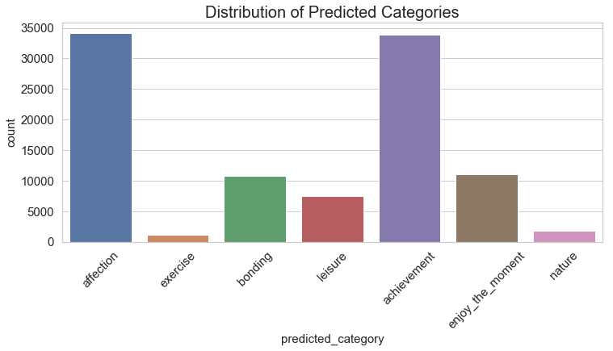

```python
plt.figure(figsize=(12,5))
ax = sns.countplot(x="predicted_category", data=happy_mn)
ax.set_xticklabels(ax.get_xticklabels(), rotation=45)
ax.tick_params(labelsize = 15)
ax.set_title("Distribution of Predicted Categories",size=20)
ax.set_xlabel(ax.get_xlabel(), size=15)
ax.set_ylabel(ax.get_ylabel(), size=15)
```

```
Text(0,0.5,'count')
```

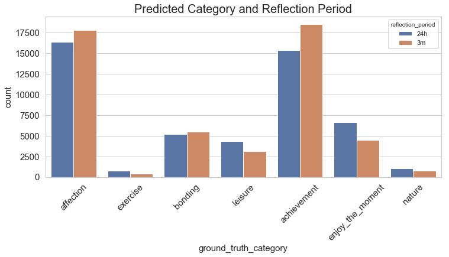

```python
plt.figure(figsize=(12,5))
ax2 = sns.countplot(x="predicted_category", hue="reflection_period", data=happy_mn)
ax2.set_xticklabels(ax2.get_xticklabels(), rotation=45)
ax2.tick_params(labelsize = 15)
ax2.set_title("Predicted Category and Reflection Period", size = 20)
ax2.set_xlabel(ax1.get_xlabel(), size=15)
ax2.set_ylabel(ax1.get_ylabel(), size=15)
```

## 2.4 word cloud

The word cloud shows most important (frequent) words in the corpus. Since affection is a very popular category, it is not surprising that we see words like friend, boyfriend, wife, daughter, son, husband that indicate close personal relationships.

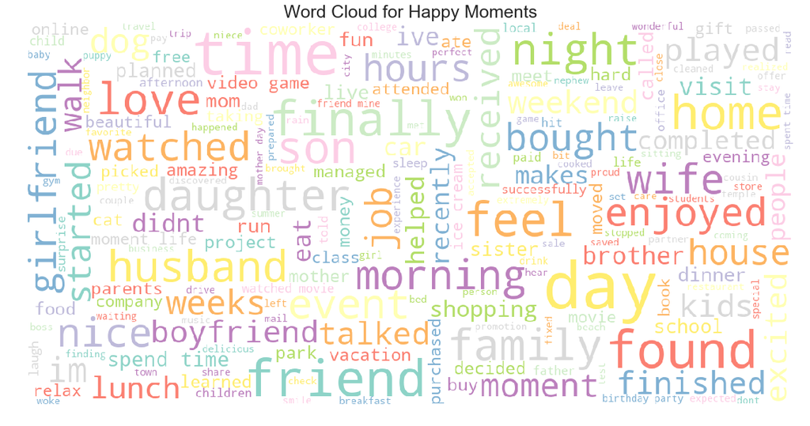

```python
from wordcloud import WordCloud

temp_data = happy_mn.dropna(subset=['text'])
word_cloud = WordCloud(max_font_size=100, width=1200, height=600, background_color='white').generate(' '.join(temp_data['text'].values))
plt.figure(figsize=(30,10))
plt.imshow(word_cloud.recolor(colormap=plt.get_cmap('Set3')))
plt.title("Word Cloud for Happy Moments", fontsize=25)
plt.axis("off")
plt.show()
```

# Part 3: TF-IDF

We treat the sentences by a common user as a document. I used TF-IDF vectorizer to converted the text into matrices. After fitting and transforming the model, there remained a total of 10841 documents and 98 important terms from the text, some of which are "baby, beautiful, birthday, buy, car," as shown below.

I also calculated the cosine similarity between documents.

```python
happy_mn.wid.describe()
# max(happy_mn.wid)
len(happy_mn.wid.unique())
```

```
10841
```

```python
# generate a list called text of length 10840
text = []
for wid in range(max(happy_mn.wid)+1):
    temp_series = happy_mn[happy_mn.wid==wid].text
    if not temp_series.empty:
        temp_sentence = ""
        for sentence in temp_series.values:
            temp_sentence = temp_sentence + str(sentence)
        text.append(temp_sentence)
```

```python
#define vectorizer parameters
from sklearn.feature_extraction.text import TfidfVectorizer
tfidf_model = TfidfVectorizer(max_df=0.9, max_features=2000,
                                min_df=0.05, stop_words='english',
                                 use_idf=True, ngram_range=(1,1))

tfidf_matrix = tfidf_model.fit_transform(text) #fit the vectorizer to happy moments

print "In total, there are " + str(tfidf_matrix.shape[0]) + \
      " documents and " + str(tfidf_matrix.shape[1]) + " terms."
```

```
In total, there are 10841 documents and 98 terms.
```

```python
tfidf_model.get_params()
selected_words = tfidf_model.get_feature_names()
selected_words[:10]
```

```
[u'baby',
 u'beautiful',
 u'birthday',
 u'book',
 u'bought',
 u'brother',
 u'brought',
 u'buy',
 u'called',
 u'car']
```

### Calculate document similarity

```python
from sklearn.metrics.pairwise import cosine_similarity
cos_matrix = cosine_similarity(tfidf_matrix)
print cos_matrix
```

```
[[1.         0.40666328 0.27277533 ... 0.04834697 0.18931957 0.29604566]
 [0.40666328 1.         0.37949107 ... 0.03275683 0.08983    0.17187196]
 [0.27277533 0.37949107 1.         ... 0.12043323 0.03806077 0.24436038]
 ...
 [0.04834697 0.03275683 0.12043323 ... 1.         0.         0.        ]
 [0.18931957 0.08983    0.03806077 ... 0.         1.         0.        ]
 [0.29604566 0.17187196 0.24436038 ... 0.         0.         1.        ]]
```

# Part 4: LDA Topic Modeling

I used the LDA to find the latent topics in the text. I manually set the number of clusters to 5, and got the topic words (most representative words) from each category. These words are shown below.

```python
from sklearn.decomposition import LatentDirichletAllocation
lda = LatentDirichletAllocation(n_components=5, learning_method = 'online')
```

```python
tfidf_matrix_lda = (tfidf_matrix * 100)
tfidf_matrix_lda = tfidf_matrix_lda.astype(int)
```

```python
lda.fit(tfidf_matrix_lda)
```

```
LatentDirichletAllocation(batch_size=128, doc_topic_prior=None,
             evaluate_every=-1, learning_decay=0.7,
             learning_method='online', learning_offset=10.0,
             max_doc_update_iter=100, max_iter=10, mean_change_tol=0.001,
             n_components=5, n_jobs=None, n_topics=None, perp_tol=0.1,
             random_state=None, topic_word_prior=None,
             total_samples=1000000.0, verbose=0)
```

```python
topic_word = lda.components_
# print topic_word.shape
# print topic_word
```

```python
n_top_words = 6
topic_keywords_list = []
print "<Document clustering result by LDA>"
for i, topic_dist in enumerate(topic_word):
    #Here we select top(n_top_words-1)
    lda_topic_words = np.array(selected_words)[np.argsort(topic_dist)][:-n_top_words:-1]
    topic_keywords_list.append(lda_topic_words.tolist())

for i in range(5):
    print "Cluster " + str(i) + " words: " + ", ".join(topic_keywords_list[i])
```

```
<Document clustering result by LDA>
Cluster 0 words: friend, daughter, visit, husband, birthday
Cluster 1 words: job, finally, told, received, money
Cluster 2 words: son, day, feel, time, event
Cluster 3 words: favorite, dinner, watched, dog, night
Cluster 4 words: played, game, car, video, won
```

# Part 5: K-Means Clustering

To validate the result from LDA, I also applied K-means clustering to cluster the documents. The topic words are pretty similar to that in LDA. From those topic words, we can see that cluster 0 is about playing games (maybe with friends), cluster 1 is about job, cluster 2 and 3 are about son and daughter, respectively, and cluster 4 are about friend and events.

I also used PCA to visualize the word vectors in the 2-D space. We can see that the orange, red, and blue groups are somewhat overlapped with each other, and indeed their semantic meaning are also close (son, daughter, home, etc.). The other two categories are more separate from the rest of the groups.

```python
from sklearn.cluster import KMeans

num_clusters = 5
km = KMeans(n_clusters=num_clusters)
km.fit(tfidf_matrix)
clusters = km.labels_.tolist()
```

```python
ranks = range(len(text))
films = {'rank': ranks, 'happy_text': text, 'cluster': clusters}
frame = pd.DataFrame(films, index = [clusters] , columns = ['rank', 'cluster'])
frame.cluster.value_counts().sort_values()
```

```
2     738
3     808
0     955
4    1702
1    6638
Name: cluster, dtype: int64
```

```python
print "<Document clustering result by K-means>"

order_centroids = km.cluster_centers_.argsort()[:, ::-1]

Cluster_keywords_summary = {}
for i in range(num_clusters):
    print "Cluster " + str(i) + " words:" ,
    Cluster_keywords_summary[i] = []

    for ind in order_centroids[i, :6]: #replace 6 with n words per cluster
        Cluster_keywords_summary[i].append(selected_words[ind])
        print selected_words[ind] + ",",
    print
```

```
<Document clustering result by K-means>
Cluster 0 words: game, video, played, friend, favorite, time,
Cluster 1 words: day, time, job, home, finally, feel,
Cluster 2 words: son, day, time, played, home, told,
Cluster 3 words: daughter, time, day, school, home, told,
Cluster 4 words: friend, time, day, birthday, family, visit,
```

```python
from sklearn import decomposition

pca = decomposition.PCA(n_components=2)
tfidf_matrix_np=tfidf_matrix.toarray()
pca.fit(tfidf_matrix_np)
X = pca.transform(tfidf_matrix_np)

xs, ys = X[:, 0], X[:, 1]

#set up colors per clusters using a dict
cluster_colors = {0: '#1b9e77', 1: '#d95f02', 2: '#7570b3', 3: '#e7298a', 4: '#66a61e'}
#set up cluster names using a dict
cluster_names = {}
for i in range(num_clusters):
    cluster_names[i] = ", ".join(Cluster_keywords_summary[i])
```

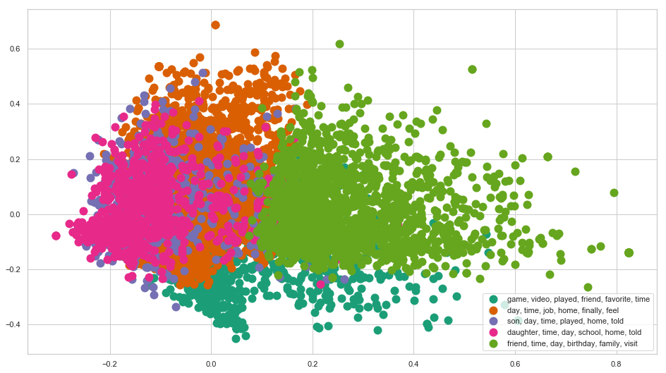

```python
%matplotlib inline

#create data frame with PCA cluster results
df = pd.DataFrame(dict(x=xs, y=ys, label=clusters))
groups = df.groupby(clusters)

# set up plot
fig, ax = plt.subplots(figsize=(16, 9))
#Set color for each cluster/group
for name, group in groups:
    ax.plot(group.x, group.y, marker='o', linestyle='', ms=12,
            label=cluster_names[name], color=cluster_colors[name],
            mec='none')

ax.legend(numpoints=1,loc=4)  #show legend with only 1 point, position is right bottom.

plt.show() #show the plot
```